# GWAS JRL 2021

J. David sur base d un script de Vincent Segura

17/03/2021

# Contexte

```r
knitr::opts_chunk$set(echo = TRUE, cache.lazy = FALSE)
```

```r
rm(list = ls())

library(anyLib)
anyLib(c("data.table", "apercu", "mlmm.gwas", "corpcor","plyr"))
```

```
## data.table     apercu  mlmm.gwas    corpcor       plyr
##       TRUE       TRUE       TRUE       TRUE       TRUE
```

# Introduction à la génétique d’association

Il n’est pas question ici de faire un cours sur la génétique d’association mais d’en expliquer rapidement le principe et d’expliquer le script par étape. La première étape est d’avoir obtenu sur les mêmes lignées des données phénotypiques et des données génotypiques sur un grand nombre de marqueurs, supposé représenté tous les morceaux de chromosomes dans lesquels gènes et marqueurs sont liés par le déséquilibre de liaison.

Pour simplifier, la valeur phénotypique est unique par lignée, elle a été obtenue dans une phase précédente qui a consisté à prendre en considération le plan d’expérience, les corrections spatiales éventuelles. Ce sont en général des BLUPS ou des BLUES.

Les valeurs des phénotypes sont modélisés de la manière suivante

$$Y=µ + X\beta + Zu + \epsilon$$
où Y est un vecteur d’une colonne et de $L$ lignes qui porte les valeurs des phénotypes X est le vecteur qui donne le nombre de copie de l’allele de référence, mettons A,à un locus où on observe seulement deux allèles comme c’est le cas des marqueurs SNP. Donc X peut prendre comme valeur 2 si la lignée est AA à ce locus, 1 si elle est hétérozygote Aa et 0 si elle est aa. $\beta$ est la pente de regression qui modifie le phénotype en fonction du nombre d’alléles A donné par X. L’effet génétique qui est modélisé est donc complètement additif. Il est déclaré comme effet fixe. C’est à dire que plus la lignée a de copies de A, plus son phénotype est modifié en proportion, en suivant la pente $\beta$. Donc vous aurez compris que c’est la valeur de $\beta$ qui détermine si il y a une association entre le marqueur et le phénotype. Il faut donc faire autant d’analyses qu’il y a de marqueurs et tester la pvalue de la nullité de la pente de chacun des marqueurs. L’hypothèse nulle est $H_0 : \beta =0$. Z est une matrice de design qui est attribue chaque valeur phénotypique à un effet multigénique pour chaque lignée $u$ qui correspond à la somme de tous les autres effets additifs des gènes polymorphes dans le génome et qui agissent sur le caractère. Ici elle est simple puisqu’il n’y a qu’une seule valeur Y pour chaque $u$. $u$ est un vecteur qui donne les valeurs additives polygéniques pour chaque lignée. Comme les lignées ne sont pas indépendantes, elles peuvent être apparentées et donc leur $u$ ne sont pas indépendantes les unes des autres et il faut donc prendre en compte le fait que posséder des allèles en commun va les faire se ressembler (leur valeur de Y sont corrélées). Donc $u$ est déclaré comme un effet aléatoire, suivant une loi normale de variance $2K\sigma_A^2$ où $\sigma_A^2$ est la variance additive polygénique du caractère et $K$ une matrice d’apparentemnt entre les lignées. Elle sera calculée avec les marqueurs. $\epsilon$ est la résiduelle, aléatoire, de variance $\sigma^2$

$$Y=µ + X_1\beta_1 + X\beta + Zu + \epsilon_2$$

# Passons à la pratique

## les données sur le génotype

### Positions des SNP sur les chromosomes

Les marqueurs sont positionné sur le génome du blé dur. Il faut donc charger le fichier des positions qui ont été obtenues de manière indirecte en blastant les séquences des marqueurs sur le génome entier. Il peut y avoir plusieurs endroits candidats. Donc attention à ne pas l’oublier.

```r
# physical positions of SNP on the Zavitan WEW2 version
load("../data/GENOTYPES/BREEDWHEAT_on_durum_physic_WEW2.Rdata")
BLAST[1,]
```

```
##     Marker_ID   Chr Mstart Mend Chrlen     start       end        v8 long simil
## 1 AX-89309359 chr7A      1   71     71 742440137 742440067 747227478   71 97.18
##   evalue
## 1  2e-25
```

Il y a 242382 SNP pour lesquels on a une position possible.

```r
dim(BLAST)
```

```
## [1] 242382     11
```

Ces SNPs sont caractérisés par de nombreuses propriétés qui seront utilisées plus tard.

```r
# toutes les infos dispo sur les snp
load("../data/GENOTYPES/caract_SNP_ALL_PHYS.Rdata")
```

## Matrice de génotypage

Les lignées ont été génotypées par une puce à ADN sur laquelle on peut lire 420 000 SNP. Les données que nous allons utiliser font partie d’un projet plus large, il faut récupérer juste les données utiles.

```r
# breed wheat genotypes
file="../data/GENOTYPES/SG_EPO_complet.Rdata"
load(file)

dim(SG)
```

```
## [1]    476 168725
```

Il y a donc 476 lignées sur 168 725 SNP.

On ne garde que ceux pour lesquels on a une position physique. Vous pourrez vérifier ensuite si vous auriez des associations avec des SNP dont vous n’avez pas idée de l’endroit où ils se trouvent. Il faudra changer le code qui suit dans ce cas.

```r
# optional Keep sNP only with an assumed physical position
liste<-which(colnames(SG) %in% BLAST[,1])
length(liste)
```

```
## [1] 112819
```

```r
ap(liste)
```

```
## [1]   1   4   7   8 101
```

```r
SG<-SG[,liste]
dim(SG)
```

```
## [1]    476 112819
```

# Phenotypes

## Les données

Ici il faudra placer vos propres données de BLUPs ou BLUE.

```r
file<-"../data/PHENOTYPES/BLUP_example.csv"
myY  <-read.table(file, head = TRUE, sep=";", dec=",")

names(myY)[1]<-"Taxa"

dim(myY)
```

```
## [1] 181   2
```

```r
myY[1:10, 1]
```

```
##  [1] ATOUDUR  EL4X_100 EL4X_101 EL4X_104 EL4X_114 EL4X_117 EL4X_118 EL4X_120
##  [9] EL4X_122 EL4X_124
## 181 Levels: ATOUDUR EL4X_100 EL4X_101 EL4X_104 EL4X_114 EL4X_117 ... SCULPTUR
```

Attention à la manière dont les codes sont donnés. Il faut que ce soit codé comme dans le fichier de génotypes.

# Keep Genotypes only if phenotyped

```r
SG<-SG[which(rownames(SG) %in% myY[,1]),]
ap(SG)
```

```
##          AX-89309359 AX-89309363 AX-89309376 AX-89309378 AX-89309726
## EL4X_240 "2"         "2"         "2"         "2"         "2"
## EL4X_356 "2"         "2"         "0"         "2"         "2"
## EL4X_476 "2"         "2"         "2"         "2"         "0"
## EL4X_241 "2"         "2"         "2"         "2"         "2"
## EL4X_16  "2"         "2"         "0"         "2"         "0"
```

```r
dim(SG)
```

```
## [1]    178 112819
```

Ici il reste 178 génotypes. Et attention aussi à ne pas garder de données phénotypiques pour lesquelles nous n’avons pas de données génotypiques.

```r
# attention il y a des génotypes qui ne sont pas dans SG
myY<-myY[which(myY[,1] %in% rownames(SG) ),]
dim(myY)
```

```
## [1] 178   2
```

```r
dim(SG)
```

```
## [1]    178 112819
```

Les deux nombres ici doivent être égaux.

## Prétraitement des données

```r
genot<-SG

# il faut que genot soit une matrice
class(genot)
```

```
## [1] "matrix"
```

```r
dim(genot)
```

```
## [1]    178 112819
```

```r
ap(genot)
```

```
##          AX-89309359 AX-89309363 AX-89309376 AX-89309378 AX-89309726
## EL4X_240 "2"         "2"         "2"         "2"         "2"
## EL4X_356 "2"         "2"         "0"         "2"         "2"
## EL4X_476 "2"         "2"         "2"         "2"         "0"
## EL4X_241 "2"         "2"         "2"         "2"         "2"
## EL4X_16  "2"         "2"         "0"         "2"         "0"
```

### Imputation of Missing data

- simple binomial Imputation

```r
noms<-rownames(genot)
genot<-apply(genot,2,as.numeric)
rownames(genot)<-noms

genot.imp <- apply(genot, 2, function(x){
  freq <- table(x)
  x[is.na(x)] <- as.integer(names(which.max(freq)))
  return(x)
})
```

### Fréquence allélique minimale

Il n’est pas raisonnable de faire une analyse si les fréquences alléliques sont trop déséquilibrées, par exemple un allèle très fréquent et l’autre très rare. Il y aurait un trop grand déséquilibre entre les effectifs des AA et des aa et la pente serait mal estimée, il pourrait y avoir des associations créées juste par quelques indididus au hasard. Donc on ne va garder que les marqueurs pour lesquels la fréquence de l’allèle minoritaire est plus grande qu’un certain seuil.

Le calcul des fréquences est facile vus comment sont codés les génotypes.

```r
p <- colMeans(genot.imp) / 2
q <- 1 - p
```

La répresentation du spectre de fréquences alléliques

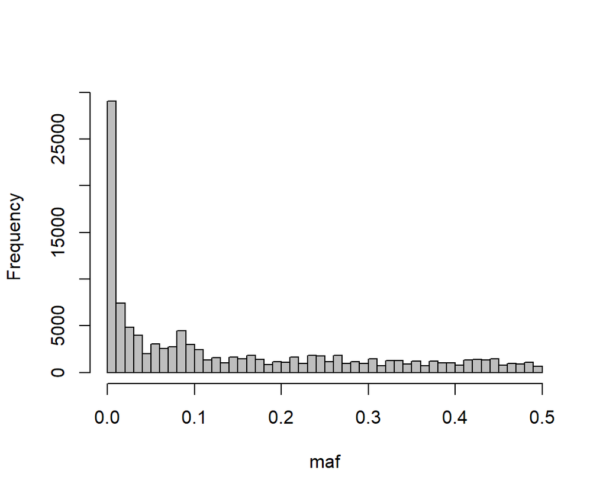

```r
maf <- apply(cbind(p, q), 1, min)
hist(maf, col = "grey", main = "", breaks = 50, xlim = c(0, 0.5))
```

On voit sur cette figure que les alléles rares sont fréquents. Ici on filtre de manière à ne garder que des MAF supérieures à 5%.

```r
sum(maf < 0.5)
```

```
## [1] 112784
```

```r
genot.ok <- genot.imp[, maf >= 0.05]
dim(genot.ok)
```

```
## [1]   178 65405
```

Il ne reste plus que 65405 marqueurs dans cet exemple.

### Physical map

Une opération importante est de créer le fichier de la carte physique.

```r
map<-BLAST[which(BLAST[,1] %in% colnames(genot.ok)),c(1,2,6)]
names(map)<-c("SNP","Chr","Pos")
head(map)
```

```
##             SNP   Chr       Pos
## 8   AX-89309369 chr4B 631948705
## 10  AX-89309371 chr1B  43228153
## 18  AX-89309376 chr7A 605815984
## 27  AX-89309722 chr5A 578939825
## 32  AX-89309726 chr2A   7484084
## 124 AX-89309734 chr3B 762124628
```

on ne garde que les SNP sélectionnés et on renomme les chromosomes de 1 à 14.

```r
map <- map[map$SNP %in% colnames(genot.ok), ]

map[,2] <-mapvalues(map[,2], from=c( "chrom",
                          "chr1A", "chr1B", "chr2A", "chr2B",
                          "chr3A", "chr3B", "chr4A", "chr4B",
                          "chr5A", "chr5B", "chr6A", "chr6B",
                          "chr7A", "chr7B")
          , to=c("chrom", 1:14))
map[,2]<-as.numeric(map[,2])

dim(map)
```

```
## [1] 65405     3
```

```r
head(map)
```

```
##             SNP Chr       Pos
## 8   AX-89309369   8 631948705
## 10  AX-89309371   2  43228153
## 18  AX-89309376  13 605815984
## 27  AX-89309722   9 578939825
## 32  AX-89309726   3   7484084
## 124 AX-89309734   6 762124628
```

```r
tail(map)
```

```
##                 SNP Chr       Pos
## 1180551 AX-89778312   9 707489011
## 1180554 AX-89778316   1  16997776
## 1180555 AX-89778318   3 355542057
## 1180559 AX-89778325   3 426083586
## 1180560 AX-89778326   7 666072491
## 1180563 AX-89778329   4  68411991
```

On les trie dans l’ordre des chromosomes et de leur positions en bp depuis le télomère du bras court.

```r
map <- map[order(map$Pos), ]
map <- map[order(map$Chr), ]
head(map)
```

```
##                 SNP Chr    Pos
## 524641  AX-89519629   1  45012
## 1071353 AX-89726564   1  98264
## 345944  AX-89445498   1 100862
## 247647  AX-89400264   1 151786
## 828617  AX-89635280   1 152065
## 303025  AX-89423540   1 152603
```

```r
tail(map)
```

```
##                 SNP Chr       Pos
## 614821  AX-89556573  14 777503232
## 452971  AX-89489367  14 777547462
## 957509  AX-89680733  14 777547777
## 713797  AX-89591720  14 777548581
## 1019901 AX-89707787  14 777549644
## 941809  AX-89673999  14 777552033
```

On peut libérer de la place mémoire.

```r
rm(genot, genot.imp, maf, p, q)
```

# Choix de la variable à analyser

La variable importante est placée dans la variable y qui sera ensuite manipulée.

## Exploration des relations

Ici il n’y a qu’une variable, c’est le numéro 2 (la première est le nom de la lignée)

```r
names(myY)
```

```
## [1] "Taxa"   "G_biom"
```

```r
i<-2
```

## préparation du vecteur phénotype

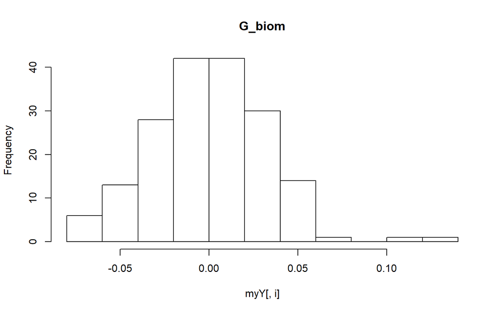

```r
hist(myY[,i], main = names(myY)[i])
```

```r
y <- myY[,i]

# passage des noms dans le rowname de y
names(y) <- myY$Taxa
```

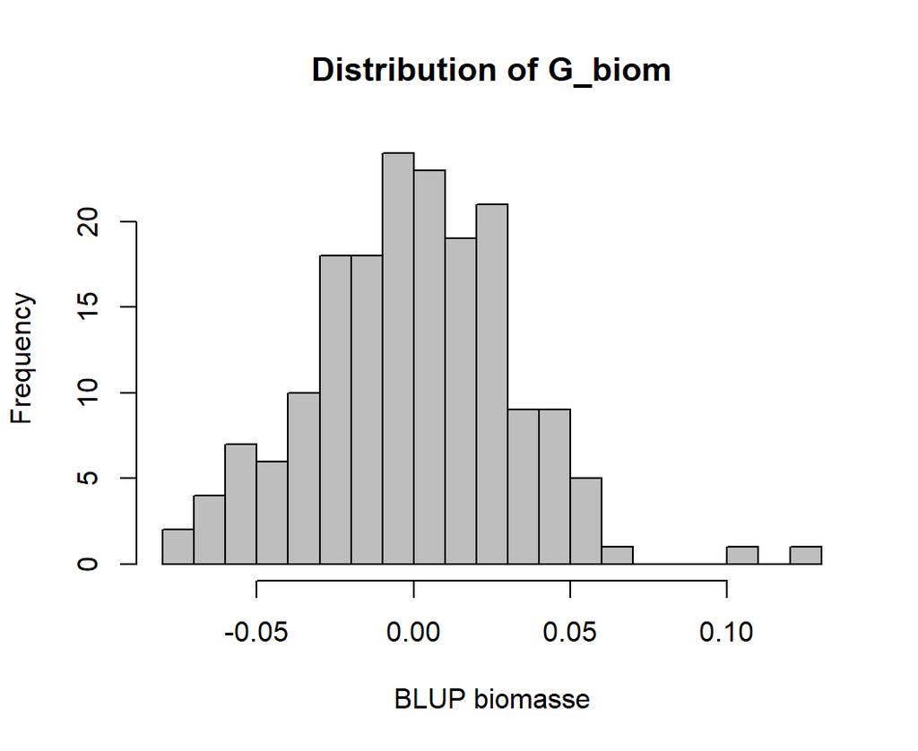

```r
# pour G y[which(y> 0.10)]<-NA

hist(y, col = "grey",  nclass=20, xlab = "BLUP biomasse", main=paste("Distribution of", names(myY)[i]))
```

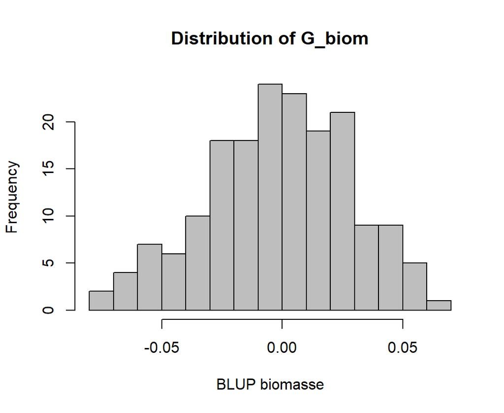

```r
# on élimine deux données (arbitraire) qui ont des valeurs extrêmes
y[which(y> 0.10)]<-NA

hist(y, col = "grey",  nclass=20, xlab = "BLUP biomasse", main=paste("Distribution of", names(myY)[i]))
```

```r
summary(y)
```

```
##       Min.    1st Qu.     Median       Mean    3rd Qu.       Max.       NA's
## -0.0735496 -0.0221090 -0.0005595 -0.0018230  0.0205224  0.0677290          2
```

# Data merge and viz

## Data check

```r
# tri des genotypes pour qu'il soient dans le meme ordre
genot.ok<-genot.ok[order(rownames(genot.ok)),]
y<-y[order(names(y))]

genot.loop<-genot.ok

# Comme il peut y avoir des données phénotypiques manquantes
if (length(which(is.na(y)))>0 ) {
     liste<- which(is.na(y))
     y <- y[-liste]
     genot.loop<-genot.loop[-liste,]
     #rownames(genot.loop)<-rownames(genot.ok)[-which(is.na(y))]
     }

dim(genot.loop)
```

```
## [1]   176 65405
```

On verifie que les deux fichiers sont dans le meme ordre et qu’il y en a autant, ca doit faire une droite

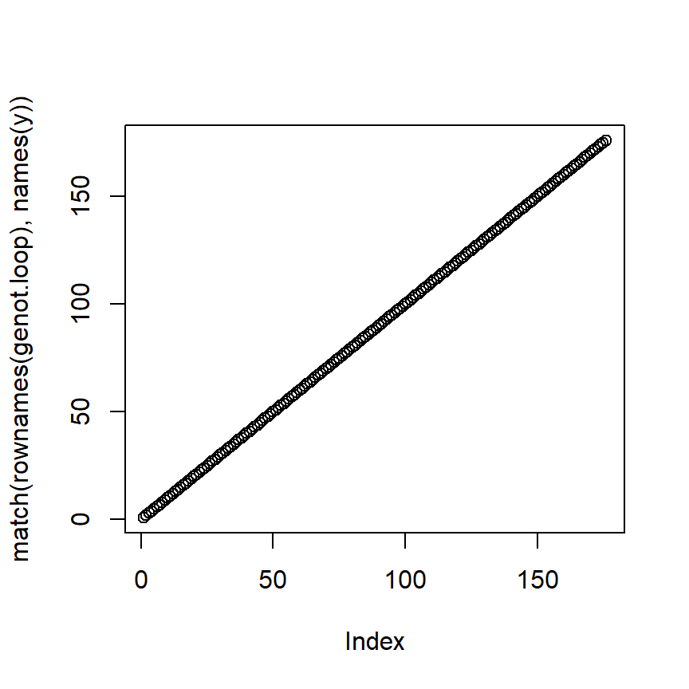

```r
plot(match(rownames(genot.loop), names(y)))
```

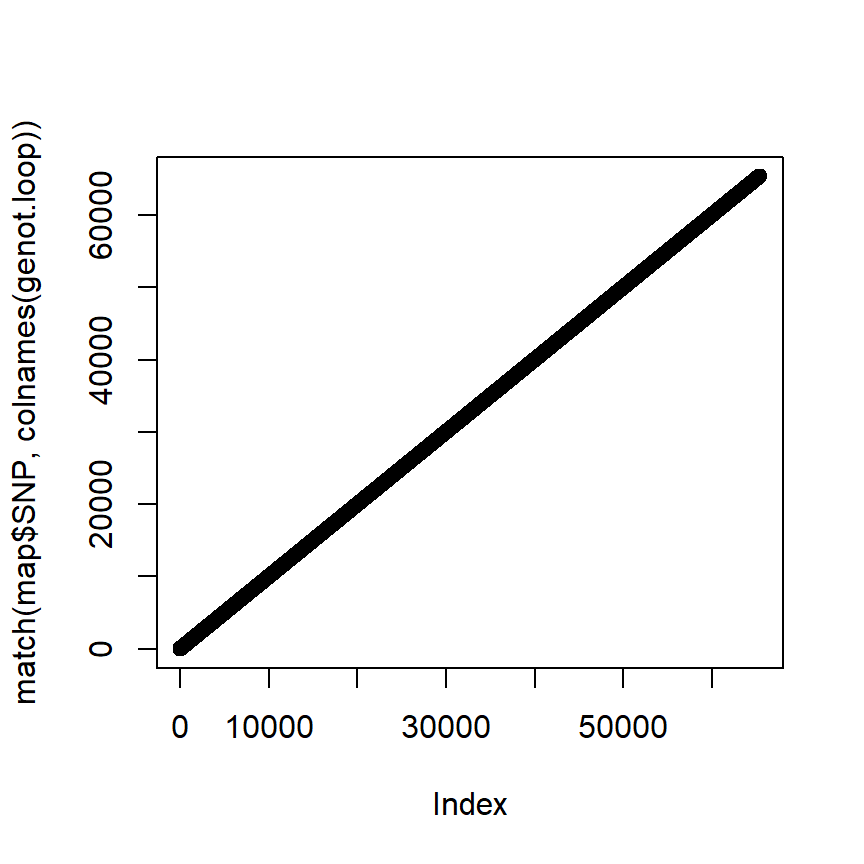

```r
# tri des marqueurs pour qu'ils soient dans l'ordre de la carte
# ne pas le faire pour avoir tous les marqueurs
genot.loop<-genot.loop[,map$SNP]
plot(match(map$SNP, colnames(genot.loop)))
```

## Calcul de la matrice de Kinship

### K Van Raden

Il s’agit du calcul de la matrice d’apparentement du modèle. Il y a beaucoup de littérature sur la meilleure méthode de calcul de cette matrice. ici on utilise une méthode dite de Van Raden, pas expliquée ici.

```r
# Calcul de la matrice d'apparentement
p <- colMeans(genot.loop) / 2
q <- 1 - p

# Ici ca sera une Van Raden centrée
genot.scaled <- scale(genot.loop, center = 2 * p, scale = sqrt(2 * p * q))

K <- tcrossprod(genot.scaled) / ncol(genot.scaled)
K <- make.positive.definite(K)
```

C’est une matrice carrée qui donne les relations deux à deux pour toutes les lignées. ici elle est 176 x 176.

Voilà la distribution de toutes les valeurs. La plupart des lignées ont un très faible apparentement.

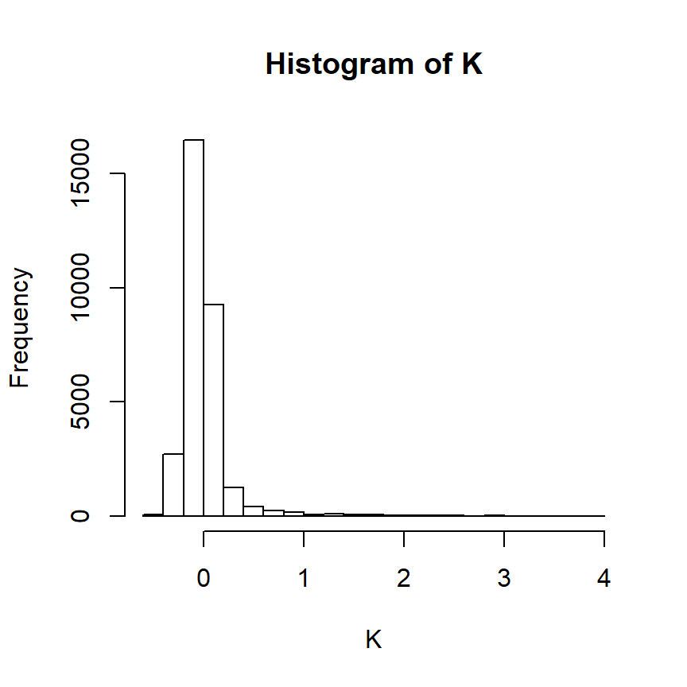

```r
hist(K)
```

```r
dim(K)
```

```
## [1] 176 176
```

# La régression

On prend une approche de regression multiple proposée par V.Segura et collaborateurs en utilisant le package mlmm.gwas. Mais il y a eu de très nombreuses variantes.

## Utilisation de mlmm.gwas

Vous reconnaitrez dans l’appel de la fonction  
**mlmm_allmodels(y, list(genot.scaled), list(K), maxsteps = 4, threshold=1e-5)** les différents membres du modèle. y le phénotype à analyser, K la matrice de Kinship, genot.scaled la matrice de tous les X, Cette fonction va donc calculer en une seule fois toutes les pvalues de tous les marqueurs. Elle va aussi utiliser un niveau de risque controlé pour les tests multiples avec threshold (vous pouvez le changer) maxsteps donne le nombre de co facteurs (marqueurs les plus significatifs) qu’il va entrer

```r
# dapres https://cran.r-project.org/web/packages/mlmm.gwas/vignettes/gwas-manual.html

# dans mlmm.gwas la matrice des genotypes doit etre centrée (c'est pas écrit qu'elle doit être reduite ? )
genot.scaled <- scale(genot.loop, center = 2 * p)

mygwas.gwas <- mlmm_allmodels(y, list(genot.scaled), list(K),
                               maxsteps = 4, threshold=1e-5)
```

[output not shown]

```r
res_mlmm <- mygwas.gwas
```

Les pValues ont été calculées selon les 4 modèles et pour tous les marqueurs. L’exploitation des résultats n’est pas des plus faciles…

Pour commencer,un graphe des -log10(Pvalues) pour tous les marqueurs, quelquesoit leur position. Est ce qu’il y en a qui dépassent le seuil ?

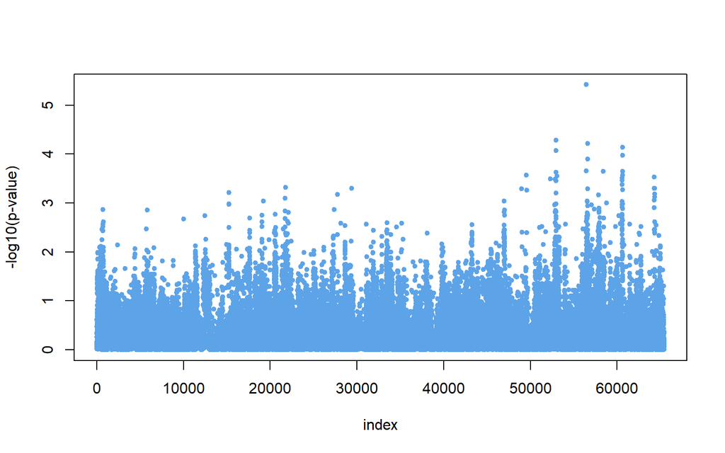

```r
# manhattab plot sans carte
manhattan.plot(res_mlmm)
```

Ensuite il y a une procédure (complexe) de choix du meilleur modèle.

```r
# Selection du modèle
sel_XX = frommlmm_toebic(list(genot.scaled), res_mlmm)
res_eBIC = eBIC_allmodels(y, sel_XX, list(K), ncol(genot.scaled))

res_eBIC
```

```
##                  BIC    ajout eBIC_0.75      LogL
## mu          503.5190  0.00000  503.5190 -244.0038
## AX-89658287 486.9708 16.63253  503.6033 -233.1444
## AX-89437601 476.8151 32.22532  509.0404 -225.4813
## AX-89689613 466.0206 47.20988  513.2304 -217.4988
```

Le meilleur modèle est celui qui a le plus petit eBIC. Ici il n’accepte aucun SNP significatif mais on va continuer quand même.

On augmente un peu le risque de première espèce.

```r
res_threshold <- threshold_allmodels(threshold=1e-4, res_mlmm)
```

```
## [1] "No p-value below the threshold at step 2"
```

Voilà le SNP qui passe la barre

```r
res_threshold
```

```
##           SNP              p-value MLMM_Step
## 1 AX-89658287 3.82243601801298e-06         1
```

## Manhattan plot

On peut maintenant regarder comment se distribuent les pvalues sur le génome physique.

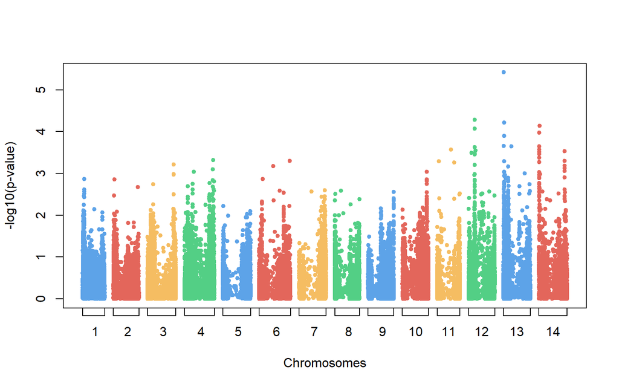

```r
mip<-map
mip$Chr<-sprintf("%2d",mip$Chr)

manhattan.plot(res_mlmm, map = mip, steps = 1, hideCofactors = FALSE, chrToPlot = "all", unit = "bp")
```

Il y a un pic sur le chromosome 13 (donc le 7A).

# visualisation des effets

On peut aussi calculer les effets alléliques (la valeur de la pente)

```r
sel_XXclass = fromeBICtoEstimation(sel_XX, res_eBIC, res_threshold)

effects = Estimation_allmodels(y, sel_XXclass, list(K))
effects
```

```
##                        BLUE Tukey.Class Frequency
## AX-89658287_00 -0.032597888           a 0.1193182
## AX-89658287_11  0.000000000           b 0.8806818
## mu              0.002066498        <NA>        NA
```

Ici le génotype 00(aa) a une différence de -0.032 avec le génotype 11 (AA).

Voilà son nom.

```r
mark_list<-names(sel_XXclass)
mark_list[1]
```

```
## [1] "AX-89658287"
```

Graphiquement,

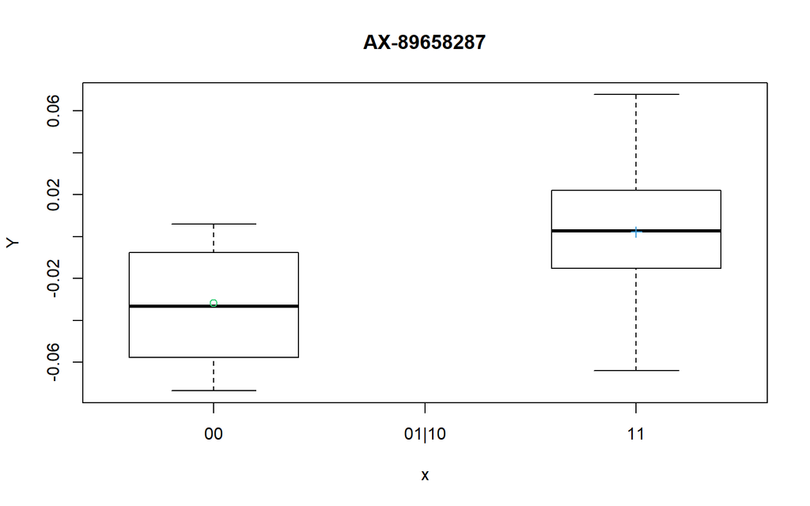

```r
# m numero du marqueur dans la liste des retenus
m<-1
genotypes.boxplot(genot.scaled, y , mark_list[m], effects)
```

Enfin il est souvent intéressant de savoir quels sont les effectifs de chaque classe.

```r
# les effectifs
table(genot.loop[,mark_list[m]])
```

```
##
##   0   2
##  21 155
```

Où est-il ?

On utilise les données connues de position

```r
map[which(map$SNP == mark_list[m]),]
```

```
##                SNP Chr      Pos
## 897237 AX-89658287  13 16856324
```

A t il des marqueurs proches qui sont liés aussi ?

## En DL ?

```r
C<-cor(genot.ok[,mark_list[m]], genot.ok)**2

liste<-which(C>0.5)
liste<-colnames(C)[liste]

map[which(map$SNP %in% liste),]
```

```
##                 SNP Chr      Pos
## 224672  AX-89394883  13 13834108
## 897237  AX-89658287  13 16856324
## 510687  AX-89516283  13 20863869
## 1109286 AX-89746215  13 21172991
```